# Fallstudie Bellabeat

Mohammad Saeed Angiz

2026-08-25

```r
library(tidyverse)
library(readr)
library(ggplot2)
library(tibble)
library(lubridate)
library(janitor)
library(scales)
library(knitr)
library(dplyr)
Sys.setlocale("LC_TIME", "C")  # englische Wochentagsnamen unabhaengig vom Systemgebietsschema
```

```
## [1] "C"
```

# Zusammenfassung

```r
tibble(
  Kennzahl = c("Ausgewertete Nutzende", "Tage mit erfasster Aktivitaet", "Naechte mit Schlafdaten",
               "Mediane Tragequote", "Durchschnittliche Sitzzeit pro Tag",
               "Naechte unter 7 Stunden Schlaf", "Tage mit 10.000 Schritten",
               "Korrelation: Sitzzeit und Schlaf"),
  Wert = c(
    as.character(n_users),
    comma(nrow(worn)),
    comma(nrow(sleep)),
    percent(median((worn |>  count(id, name = "d") |>
      left_join(daily |>  distinct(id, period) |>
        left_join(daily |>  group_by(period) |>
          summarise(w = as.numeric(max(date) - min(date)) + 1, .groups = "drop"),
          by = "period") |>  group_by(id) |>
        summarise(w = sum(w), .groups = "drop"), by = "id") |>
      mutate(r = d / w))$r), 1),
    paste0(round(mean(worn$sedentary_minutes) / 60, 1), " Stunden"),
    percent(mean(sleep$hours_asleep < 7), 0.1),
    percent(mean(worn$total_steps >= 10000), 0.1),
    round(cor((worn |>  inner_join(sleep, by = c("id", "date")))$sedentary_minutes,
              (worn |>  inner_join(sleep, by = c("id", "date")))$hours_asleep), 2)
  )
) |>  kable(caption = "Wichtigste Kennzahlen")
```

Wichtigste Kennzahlen

| Kennzahl | Wert |
| --- | --- |
| Ausgewertete Nutzende | 35 |
| Tage mit erfasster Aktivitaet | 1,235 |
| Naechte mit Schlafdaten | 882 |
| Mediane Tragequote | 63% |
| Durchschnittliche Sitzzeit pro Tag | 15.9 Stunden |
| Naechte unter 7 Stunden Schlaf | 49.1% |
| Tage mit 10.000 Schritten | 34.0% |
| Korrelation: Sitzzeit und Schlaf | -0.48 |

**Die drei wichtigsten Empfehlungen:** das feste Ziel von 10.000 Schritten durch ein anpassungsfaehiges Ziel ersetzen; die Bellabeat-App ueber den Zusammenhang “weniger sitzen, besser schlafen” vermarkten; und Benachrichtigungen auf die beiden Stunden legen, in denen sich die Nutzenden ohnehin bewegen.

# 1. Fragen: Zusammenfassung der Geschaeftsaufgabe

> **Ergebnis 1: Eine klare Zusammenfassung der Geschaeftsaufgabe**

Bellabeat ist ein Hightech-Hersteller von gesundheitsorientierten Produkten fuer Frauen, gegruendet 2013 von Urška Sršen und Sando Mur. Die Produktlinie umfasst die Bellabeat-App, den Leaf-Tracker, die Time-Uhr, die Spring-Wasserflasche und eine Abonnement-Mitgliedschaft.

Urška Sršen ist ueberzeugt, dass die Auswertung von Fitnessdaten intelligenter Geraete neues Wachstum erschliessen kann. Sie hat das Marketing-Analyseteam gebeten, Nutzungsdaten von **intelligenten Geraeten anderer Hersteller** zu analysieren, **ein Bellabeat-Produkt** auszuwaehlen und Empfehlungen auf hoher Ebene fuer die Marketingstrategie zu erarbeiten.

### Die Geschaeftsaufgabe

> Ermitteln, wie Verbraucherinnen und Verbraucher intelligente Geraete anderer Hersteller tatsaechlich nutzen, und bestimmen, welche der daraus erkennbaren Verhaltensluecken Bellabeat durch die Vermarktung der Bellabeat-App schliessen kann.

### Leitfragen, die dieser Bericht beantwortet

1. Welche Trends gibt es bei der Nutzung intelligenter Geraete?
2. Wie lassen sich diese Trends auf Bellabeat-Kundinnen uebertragen?
3. Wie koennen diese Trends die Marketingstrategie von Bellabeat beeinflussen?

### Wichtigste Beteiligte

| Beteiligte Person | Rolle | Was sie daraus braucht |
| --- | --- | --- |
| Urška Sršen | Mitgruenderin, Chief Creative Officer | Wachstumschancen mit belastbarer Grundlage |
| Sando Mur | Mitgruender, Geschaeftsleitung | Analytisch fundierte Schlussfolgerungen |
| Marketing-Analyseteam | Kolleginnen und Kollegen | Eine reproduzierbare Basis fuer Kampagnenentscheidungen |

### Ausgewaehltes Produkt

Die **Bellabeat-App**. Sie verbindet alle Geraete der Produktlinie, ist die Oberflaeche, ueber die Verhaltensimpulse ausgeliefert werden, und traegt das Abonnement. Erkenntnisse ueber Verhalten lassen sich dort am schnellsten und guenstigsten umsetzen.

# 2. Vorbereiten: Beschreibung der Datenquellen

> **Ergebnis 2: Eine Beschreibung aller verwendeten Datenquellen**

## Quelle und Lizenz

[Datensatz auf Kaggle herunterladen](https://www.kaggle.com/datasets/arashnic/fitbit)

| Punkt | Details |
| --- | --- |
| Datensatz | FitBit Fitness Tracker Data |
| Bereitgestellt von | Mobius, ueber [Kaggle](https://www.kaggle.com/datasets/arashnic/fitbit) |
| Lizenz | CC0 gemeinfrei, keine Nutzungsbeschraenkung |
| Erhebung | Umfrage ueber Amazon Mechanical Turk, 12. Maerz bis 12. Mai 2016 |
| Einwilligung | Die Teilnehmenden haben der Uebermittlung ihrer Trackerdaten ausdruecklich zugestimmt |
| Datenschutz | Keine Namen, Adressen oder demografischen Angaben; Nutzende nur ueber eine numerische ID identifiziert |
| Speicherung | Lokal in datierten Unterordnern abgelegt; die Originaldateien wurden nicht veraendert |

Da die Daten unter CC0 stehen und keine personenbezogenen Kennungen enthalten, bestehen fuer diese Analyse keine lizenz-, datenschutz- oder sicherheitsrechtlichen Huerden. Die gesamte Bereinigung erfolgte an Kopien; die Quelldateien im `.csv`-Format wurden nie ueberschrieben.

## Wie die Daten aufgebaut sind

Der Datensatz wird als **zwei Exportordner fuer aufeinanderfolgende Monate** ausgeliefert:

- `mturkfitbit_export_3.12.16-4.11.16`, 12. Maerz bis 11. April 2016
- `mturkfitbit_export_4.12.16-5.12.16`, 12. April bis 12. Mai 2016

Beide enthalten dieselben Messwerte auf vier Detailebenen: Tag, Stunde, Minute und Sekunde, jeweils im langen (`Narrow`) und im breiten Format.

**Die meisten veroeffentlichten Analysen dieses Datensatzes nutzen nur den zweiten Ordner.** Beide Ordner haben ein identisches Schema in `dailyActivity_merged.csv`, deshalb kombiniert diese Analyse sie:

```r
tibble(
  Umfang = c("Uebliche Analyse mit einem Ordner", "Diese Analyse (beide Ordner)"),
  Nutzende = c(33, n_users),
  `Abgedeckte Tage` = c(31, as.numeric(max(daily$date) - min(daily$date)) + 1),
  `Naechte mit Schlafdaten` = c(410, nrow(sleep))
) |>  kable(caption = "Die Kombination beider Exportordner verdoppelt die Datengrundlage annaehernd")
```

Die Kombination beider Exportordner verdoppelt die Datengrundlage annaehernd

| Umfang | Nutzende | Abgedeckte Tage | Naechte mit Schlafdaten |
| --- | --- | --- | --- |
| Uebliche Analyse mit einem Ordner | 33 | 31 | 410 |
| Diese Analyse (beide Ordner) | 35 | 62 | 882 |

## Ausgewaehlte Dateien und die Gruende dafuer

```r
steps_only <- read_csv(file.path(P2, "dailySteps_merged.csv"), show_col_types = FALSE)
activity   <- read_csv(file.path(P2, "dailyActivity_merged.csv"), show_col_types = FALSE)

check <- steps_only |>  rename(day = ActivityDay) |>
  inner_join(activity |>  rename(day = ActivityDate), by = c("Id", "day"))

cat("Verglichene Nutzertage:", nrow(check), "\n")
```

```
## Verglichene Nutzertage: 578
```

```r
cat("Schrittzahlen in jeder Zeile identisch:", all(check$StepTotal == check$TotalSteps), "\n")
```

```
## Schrittzahlen in jeder Zeile identisch: TRUE
```

| Verwendete Datei | Zweck |
| --- | --- |
| `dailyActivity_merged` | Schritte, Distanz, Intensitaetsminuten und Kalorien pro Tag |
| `hourlySteps_merged` | Aktivitaetsmuster im Tagesverlauf |
| `sleepDay_merged` | Naechtliche Schlafsummen, Zeitraum April |
| `minuteSleep_merged` | Zu Naechten aggregiert, erweitert die Schlafabdeckung auf Maerz |
| `weightLogInfo_merged` | Nutzung von Funktionen und Verhalten bei manueller Eingabe |

`heartrate_seconds_merged.csv` wurde ausgeschlossen: 86 MB fuer nur 14 von 35 Nutzenden, eine zu kleine Teilstichprobe fuer eine belastbare Aussage. Die minutengenauen Aktivitaetsdateien wurden als redundant zu den stuendlichen und taeglichen Aggregaten ausgeschlossen.

## Datenintegritaet und Glaubwuerdigkeit: erfuellt der Datensatz ROCCC?

```r
tibble(
  Kriterium = c("Reliable (verlaesslich)", "Original (urspruenglich)",
                "Comprehensive (vollstaendig)", "Current (aktuell)",
                "Cited (belegt)"),
  Bewertung = c("Schwach", "Schwach", "Schwach", "Mangelhaft", "Gut"),
  Details = c(
    paste0(n_users, " selbst ausgewaehlte Teilnehmende; keine unabhaengige Pruefung"),
    "Weitergabe durch Dritte, nicht von Fitbit oder Bellabeat erhoben",
    "Weder Alter noch Geschlecht, Groesse, Ort oder gesundheitliche Ausgangslage erfasst",
    "2016 erhoben; Hardware und Nutzererwartungen haben sich seitdem veraendert",
    "Klar belegt und offen unter CC0 lizenziert"
  )
) |>  kable(caption = "ROCCC-Bewertung der FitBit Fitness Tracker Data")
```

ROCCC-Bewertung der FitBit Fitness Tracker Data

| Kriterium | Bewertung | Details |
| --- | --- | --- |
| Reliable (verlaesslich) | Schwach | 35 selbst ausgewaehlte Teilnehmende; keine unabhaengige Pruefung |
| Original (urspruenglich) | Schwach | Weitergabe durch Dritte, nicht von Fitbit oder Bellabeat erhoben |
| Comprehensive (vollstaendig) | Schwach | Weder Alter noch Geschlecht, Groesse, Ort oder gesundheitliche Ausgangslage erfasst |
| Current (aktuell) | Mangelhaft | 2016 erhoben; Hardware und Nutzererwartungen haben sich seitdem veraendert |
| Cited (belegt) | Gut | Klar belegt und offen unter CC0 lizenziert |

**Dieser Datensatz erfuellt ROCCC nicht gut, und das wird vor den Ergebnissen festgehalten, nicht danach.** Die Stichprobe ist klein und selbst ausgewaehlt, und sie enthaelt **kein Feld zum Geschlecht**. Das ist eine erhebliche Einschraenkung bei einer Analyse fuer ein Unternehmen, das ausschliesslich an Frauen verkauft. Jedes Ergebnis unten ist ein Richtungssignal, das an Bellabeats eigenen Daten zu pruefen ist, keine Grundlage fuer Budgetentscheidungen.

Sršen hat angeregt, einen zusaetzlichen Datensatz einzubeziehen, um diese Grenzen zu adressieren. Am wertvollsten waeren Bellabeats eigene App-Telemetriedaten, in denen Geschlecht, Alter und Produktlinie bekannt sind.

# 3. Verarbeiten: Dokumentation der Datenbereinigung

> **Ergebnis 3: Dokumentation jeder Bereinigung und Umformung der Daten**

## Gewaehlte Werkzeuge

**R mit dem tidyverse**, aus drei Gruenden: Der Datensatz sprengt auf Minutenebene den komfortablen Arbeitsbereich von Excel (ueber 1,3 Millionen Zeilen); jeder Bereinigungsschritt ist als Code festgehalten und damit reproduzierbar und pruefbar; und dieselbe Umgebung erledigt Bereinigung, Statistik und Visualisierung, ohne zwischen Werkzeugen exportieren zu muessen. Dieses Dokument ist in R Markdown geschrieben, jede genannte Zahl entsteht daher beim Rendern und wird nicht von Hand eingetragen.

## Pruefung auf Fehler

```r
tibble(
  Pruefung = c("Doppelte Zeilen in der Tagesaktivitaet",
               "Doppelte Zeilen im Schlaf (April-Tageswerte)",
               "Fehlende Werte in der Tagesaktivitaet",
               "Tage mit null Schritten",
               "Gewichtseintraege ohne Koerperfettwert"),
  Ergebnis = c(
    sum(duplicated(daily_raw)),
    sum(duplicated(sleep_apr_raw)),
    sum(is.na(daily_raw)),
    sum(!daily$is_wear_day),
    sum(is.na(weight$fat))
  )
) |>  kable(caption = "Integritaetspruefungen vor jeder Analyse")
```

Integritaetspruefungen vor jeder Analyse

[output not shown]

## Durchgefuehrte Bereinigungsschritte

1. **Beide Exportordner zusammengefuehrt** fuer Tagesaktivitaet, stuendliche Schritte und Gewicht, nachdem die identischen Schemata bestaetigt waren. Eine Spalte `period` haelt fest, aus welchem Zeitraum jede Zeile stammt.
2. **Spaltennamen vereinheitlicht** zu `snake_case` mit `janitor::clean_names()`.
3. **Datumsangaben aus Text geparst.** `read_csv()` importiert `"4/12/2016"` als Zeichenkette; `lubridate::mdy()` und `mdy_hms()` wandeln diese in Datumsobjekte um, damit sie sortiert, gefiltert und nach Wochentag gruppiert werden koennen.
4. **Doppelte Datensaetze entfernt.** `sleepDay_merged.csv` enthaelt drei exakt identische Zeilen, ein dokumentierter Mangel dieses Datensatzes. Die Entfernung von Duplikaten ueber `id` und `date` wurde auf jede Tabelle angewendet, als Absicherung an der Ordnergrenze.
5. **Tage ohne Tragen getrennt behandelt.**
6. **Maerz-Schlafdaten auf Minutenebene zu Nachtsummen aggregiert.**
7. **Abgeleitete Felder:** Wochentag, gesamte Aktivminuten, Schlafstunden, Wachminuten im Bett, Schlafeffizienz und Tragequote pro Nutzendem.

## Umgang mit Tagen ohne Tragen

138 Zeilen weisen null Schritte auf, zusammen mit nahezu einem vollen Tag an Sitzminuten. Sie stehen fuer ein Geraet am Ladekabel, nicht fuer eine Person, die 24 Stunden bewegungslos war:

```r
daily |>
  group_by(`Art des Tages` = ifelse(is_wear_day, "Geraet getragen", "Null Schritte erfasst")) |>
  summarise(Tage = n(),
            `Mittlere Sitzminuten` = round(mean(sedentary_minutes)),
            `Mittlere Kalorien` = round(mean(calories)), .groups = "drop") |>
  kable(caption = "Tage mit null Schritten liegen im Mittel nahe bei 1.440 Sitzminuten, was bestaetigt, dass das Geraet nicht getragen wurde")
```

Tage mit null Schritten liegen im Mittel nahe bei 1.440 Sitzminuten, was bestaetigt, dass das Geraet nicht getragen wurde

| Art des Tages | Tage | Mittlere Sitzminuten | Mittlere Kalorien |
| --- | --- | --- | --- |
| Geraet getragen | 1235 | 952 | 2336 |
| Null Schritte erfasst | 138 | 1367 | 1621 |

Diese Zeilen wurden **aus allen Aktivitaetsmittelwerten ausgeschlossen**, aber **fuer die Analyse der Geraetenutzung behalten**, wo sie der direkte Beleg dafuer sind, wie oft der Tracker getragen wird. Sie in die Mittelwerte einzubeziehen wuerde die Aktivitaet um rund 10 Prozent zu niedrig ausweisen.

## Erweiterung der Schlafabdeckung auf den Maerz

`sleepDay_merged.csv` existiert nur im April-Ordner. Diese Datei allein zu nutzen wuerde bedeuten, Aktivitaet aus beiden Monaten heranzuziehen, Schlaf aber nur aus einem. `minuteSleep_merged.csv` deckt den Maerz auf Minutenebene ab. Dort ist `value` codiert als 1 = schlafend, 2 = unruhig, 3 = wach, und jede Zeile steht fuer eine Minute im Bett. Die Zeilen pro Nacht zu zaehlen ergibt die Zeit im Bett; `value == 1` zu zaehlen ergibt die Schlafminuten. Das sind genau die beiden Groessen, die auch die April-Datei ausweist.

**Erklaerte Annahme:** Schlaf ueberschreitet Mitternacht, eine Gruppierung nach Kalenderdatum wuerde eine einzelne Nacht auf zwei Datensaetze aufteilen. Sechs Stunden abzuziehen, bevor das Datum gebildet wird, ordnet die Minuten vor Tagesanbruch der vorherigen Nacht zu. Datensaetze unter 60 Minuten wurden als Fragmente verworfen, nicht als Naechte gewertet. Diese Grenze bei 6 Uhr morgens ist eine Ermessensentscheidung. Den Maerz vollstaendig auszuschliessen reduziert die Datengrundlage von 882 auf 410 Naechte, ohne die Richtung oder Bedeutung eines Ergebnisses zu veraendern.

## Pruefung der bereinigten Daten

```r
tibble(
  Tabelle = c("Tagesaktivitaet (Tage mit Tragen)", "Schlaf", "Stuendliche Schritte", "Gewichtsprotokolle"),
  Zeilen = c(nrow(worn), nrow(sleep), nrow(hourly), nrow(weight)),
  Nutzende = c(n_distinct(worn$id), n_distinct(sleep$id),
               n_distinct(hourly$id), n_distinct(weight$id)),
  `Zeitraum` = c(
    paste(format(min(worn$date), "%d.%m."), "bis", format(max(worn$date), "%d.%m.%Y")),
    paste(format(min(sleep$date), "%d.%m."), "bis", format(max(sleep$date), "%d.%m.%Y")),
    paste(format(min(as_date(hourly$ts)), "%d.%m."), "bis", format(max(as_date(hourly$ts)), "%d.%m.%Y")),
    paste(format(min(weight$date), "%d.%m."), "bis", format(max(weight$date), "%d.%m.%Y"))
  )
) |>  kable(caption = "Bereinigte Tabellen, bereit fuer die Analyse")
```

Bereinigte Tabellen, bereit fuer die Analyse

| Tabelle | Zeilen | Nutzende | Zeitraum |
| --- | --- | --- | --- |
| Tagesaktivitaet (Tage mit Tragen) | 1235 | 35 | 12.03. bis 12.05.2016 |
| Schlaf | 882 | 25 | 11.03. bis 12.05.2016 |
| Stuendliche Schritte | 46008 | 35 | 12.03. bis 12.05.2016 |
| Gewichtsprotokolle | 98 | 13 | 30.03. bis 12.05.2016 |

# 4. Analysieren: Zusammenfassung der Analyse

> **Ergebnis 4: Eine Zusammenfassung der Analyse**

Die Analyse verlief in vier Durchgaengen. **Deskriptive Statistik** legte die Ausgangswerte fuer Aktivitaet, Schlaf und Kalorien im Vergleich zu veroeffentlichten Gesundheitsrichtwerten fest. **Segmentierung auf Nutzerebene** gruppierte die Teilnehmenden nach durchschnittlichen Tagesschritten und nach Tragequote, wobei immer zuerst pro Person aggregiert wurde, bevor Personen verglichen wurden, damit Teilnehmende mit mehr erfassten Tagen die Mittelwerte nicht dominieren. **Zeitliche Aggregation** untersuchte die Aktivitaet nach Tagesstunde und Wochentag. **Korrelation und Regression** pruefte die Zusammenhaenge zwischen Schritten, Kalorien, Sitzzeit und Schlafdauer.

`Die zentrale Ueberraschung:` Die Groesse, die am staerksten mit Schlaf zusammenhaengt, ist nicht die Schrittzahl, sondern die **Sitzzeit**, und der Zusammenhang ist rund dreimal staerker. Das verschiebt die Marketingaussage von “mehr Sport” hin zu “weniger sitzen”. Das ist eine deutlich niedrigere Huerde fuer die Nutzenden und eine Aussage, die derzeit kein grosser Wettbewerber trifft.

```r
sa <- worn |> inner_join(sleep, by = c("id", "date"))

tibble(
  Zusammenhang = c("Tagesschritte und verbrannte Kalorien",
                   "Sitzminuten und verbrannte Kalorien",
                   "Tagesschritte und Schlafstunden",
                   "Sitzminuten und Schlafstunden"),
  `Pearson r` = c(
    round(cor(worn$total_steps, worn$calories), 3),
    round(cor(worn$sedentary_minutes, worn$calories), 3),
    round(cor(sa$total_steps, sa$hours_asleep), 3),
    round(cor(sa$sedentary_minutes, sa$hours_asleep), 3)
  ),
  n = c(nrow(worn), nrow(worn), nrow(sa), nrow(sa))
) |>  kable(caption = "Geprüfte Korrelationen. Nur Zusammenhang, die Wirkungsrichtung ist nicht geprueft.")
```

Geprüfte Korrelationen. Nur Zusammenhang, die Wirkungsrichtung ist nicht geprueft.

| Zusammenhang | Pearson r | n |
| --- | --- | --- |
| Tagesschritte und verbrannte Kalorien | 0.563 | 1235 |
| Sitzminuten und verbrannte Kalorien | 0.033 | 1235 |
| Tagesschritte und Schlafstunden | -0.150 | 603 |
| Sitzminuten und Schlafstunden | -0.483 | 603 |

# 5. Teilen: Visualisierungen und wichtigste Ergebnisse

> **Ergebnis 5: Unterstuetzende Visualisierungen und wichtigste Ergebnisse**

## Ergebnis 1: Das Geraet wird abgelegt, und das haeufig

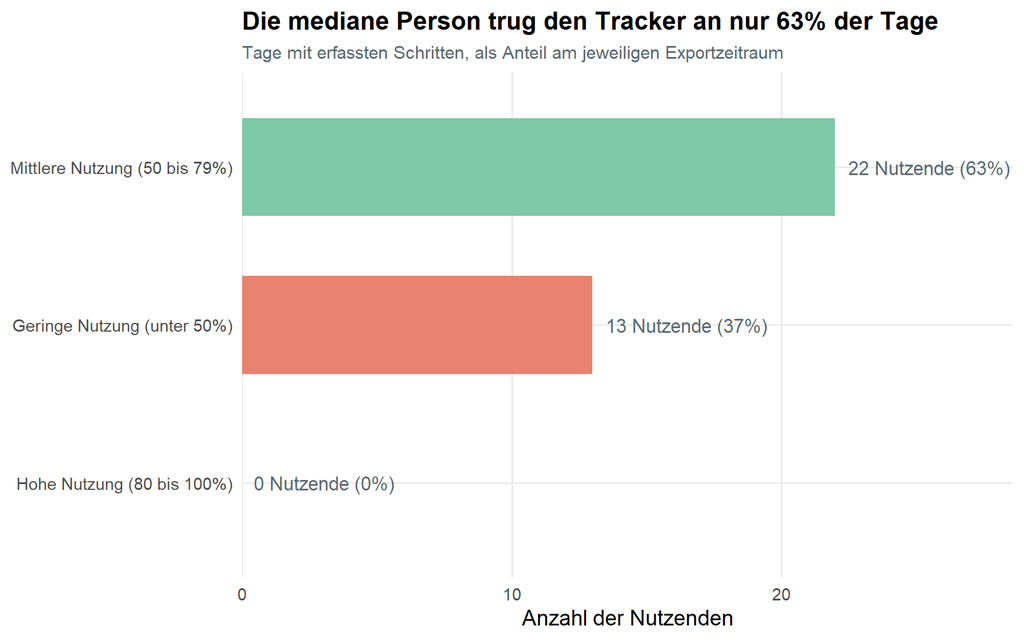

```r
period_len <- daily |>  group_by(period) |>
  summarise(days = as.numeric(max(date) - min(date)) + 1, .groups = "drop")

user_window <- daily |>  distinct(id, period) |>
  left_join(period_len, by = "period") |>
  group_by(id) |>  summarise(window_days = sum(days), .groups = "drop")

usage <- worn |>  count(id, name = "wear_days") |>
  left_join(user_window, by = "id") |>
  mutate(wear_rate = wear_days / window_days,
         segment = case_when(wear_rate >= 0.80 ~ "Hohe Nutzung (80 bis 100%)",
                             wear_rate >= 0.50 ~ "Mittlere Nutzung (50 bis 79%)",
                             TRUE              ~ "Geringe Nutzung (unter 50%)") |>
           factor(levels = c("Hohe Nutzung (80 bis 100%)", "Mittlere Nutzung (50 bis 79%)",
                             "Geringe Nutzung (unter 50%)")))

usage_sum <- usage |>  count(segment, .drop = FALSE) |>  mutate(pct = n / sum(n))

ggplot(usage_sum, aes(reorder(segment, n), n, fill = segment)) +
  geom_col(width = .62) +
  geom_text(aes(label = paste0(n, " Nutzende (", percent(pct, 1), ")")),
            hjust = -0.08, size = 3.8, colour = SLATE) +
  coord_flip() + scale_y_continuous(expand = expansion(c(0, .3))) +
  scale_fill_manual(values = c(TEAL, MINT, CORAL), guide = "none") +
  labs(title = paste0("Die mediane Person trug den Tracker an nur ",
                      percent(median(usage$wear_rate), 1), " der Tage"),
       subtitle = "Tage mit erfassten Schritten, als Anteil am jeweiligen Exportzeitraum",
       x = NULL, y = "Anzahl der Nutzenden") + theme_bb
```

Die mediane Person erfasste an 63% der verfuegbaren Tage Schritte. **Keine einzige teilnehmende Person** trug das Geraet an `80%` oder mehr der Tage, und 13 trugen es an weniger als der Haelfte.

**Warum das wichtig ist:** Ein Tracker, der ein Drittel seines Lebens in einer Schublade verbringt, kann weder zu Schlaf noch zu Stress oder Zyklus verlaessliche Erkenntnisse liefern. Die Nutzungshaeufigkeit ist die bindende Grenze fuer jede weitere Funktion.

## Ergebnis 2: Das Ziel von 10.000 Schritten ist eine Mauer, kein Ziel

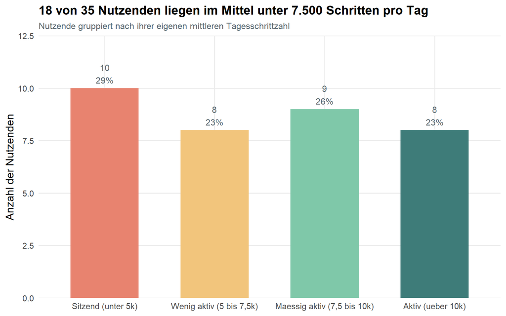

```r
user_avg <- worn |>  group_by(id) |>
  summarise(avg_steps = mean(total_steps), .groups = "drop") |>
  mutate(level = case_when(avg_steps < 5000  ~ "Sitzend (unter 5k)",
                           avg_steps < 7500  ~ "Wenig aktiv (5 bis 7,5k)",
                           avg_steps < 10000 ~ "Maessig aktiv (7,5 bis 10k)",
                           TRUE              ~ "Aktiv (ueber 10k)") |>
           factor(levels = c("Sitzend (unter 5k)", "Wenig aktiv (5 bis 7,5k)",
                             "Maessig aktiv (7,5 bis 10k)", "Aktiv (ueber 10k)")))

lvl <- user_avg |>  count(level, .drop = FALSE) |>  mutate(pct = n / sum(n))

ggplot(lvl, aes(level, n, fill = level)) +
  geom_col(width = .62) +
  geom_text(aes(label = paste0(n, "\n", percent(pct, 1))),
            vjust = -0.25, size = 3.6, colour = SLATE) +
  scale_y_continuous(expand = expansion(c(0, .25))) +
  scale_fill_manual(values = c(CORAL, SAND, MINT, TEAL), guide = "none") +
  labs(title = paste0(sum(lvl$n[1:2]), " von ", sum(lvl$n),
                      " Nutzenden liegen im Mittel unter 7.500 Schritten pro Tag"),
       subtitle = "Nutzende gruppiert nach ihrer eigenen mittleren Tagesschrittzahl",
       x = NULL, y = "Anzahl der Nutzenden") + theme_bb
```

Die mittlere Tagesschrittzahl lag bei 8,057, der Median bei 7,623. Nur 34.0% der Tage erreichten 10.000 Schritte.

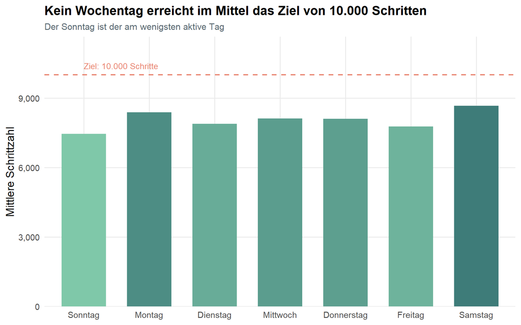

```r
worn |>  group_by(weekday) |>
  summarise(avg_steps = mean(total_steps), .groups = "drop") |>
  ggplot(aes(weekday, avg_steps, fill = avg_steps)) +
  geom_col(width = .68) +
  geom_hline(yintercept = 10000, linetype = "dashed", colour = CORAL, linewidth = .7) +
  annotate("text", x = 1, y = 10400, label = "Ziel: 10.000 Schritte",
           colour = CORAL, size = 3.2, hjust = 0) +
  scale_x_discrete(labels = WOCHENTAGE) +
  scale_fill_gradient(low = MINT, high = TEAL, guide = "none") +
  scale_y_continuous(labels = comma, expand = expansion(c(0, .12))) +
  labs(title = "Kein Wochentag erreicht im Mittel das Ziel von 10.000 Schritten",
       subtitle = "Der Sonntag ist der am wenigsten aktive Tag",
       x = NULL, y = "Mittlere Schrittzahl") +
  theme_bb
```

**Warum das wichtig ist:** Fuer die Haelfte der Nutzenden ist das voreingestellte Ziel unerreichbar. Ein Ziel, das taeglich verfehlt wird, wirkt nicht mehr motivierend, sondern erinnert an das Scheitern.

## Ergebnis 3: Das Problem ist das Sitzen, nicht der fehlende Sport

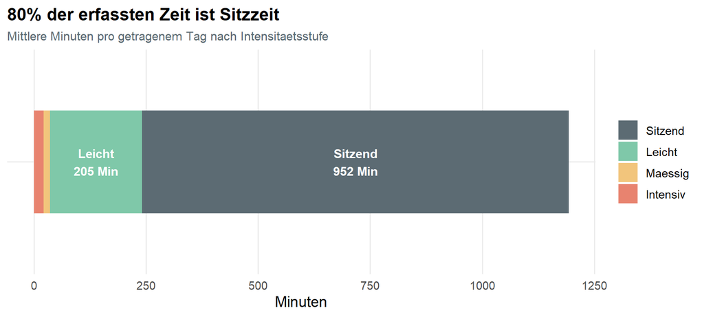

```r
mins <- worn |>
  summarise(Sitzend = mean(sedentary_minutes), Leicht = mean(lightly_active_minutes),
            Maessig = mean(fairly_active_minutes), Intensiv = mean(very_active_minutes)) |>
  pivot_longer(everything(), names_to = "intensity", values_to = "minutes") |>
  mutate(pct = minutes / sum(minutes),
         intensity = factor(intensity, levels = c("Sitzend", "Leicht", "Maessig", "Intensiv")))

ggplot(mins, aes("", minutes, fill = intensity)) +
  geom_col(width = .55) +
  geom_text(aes(label = ifelse(pct > .03, paste0(intensity, "\n", round(minutes), " Min"), "")),
            position = position_stack(vjust = .5), size = 3.6,
            colour = "white", fontface = "bold") +
  coord_flip() + scale_fill_manual(values = c(SLATE, MINT, SAND, CORAL)) +
  labs(title = paste0(percent(mins$pct[mins$intensity == "Sitzend"], 1),
                      " der erfassten Zeit ist Sitzzeit"),
       subtitle = "Mittlere Minuten pro getragenem Tag nach Intensitaetsstufe",
       x = NULL, y = "Minuten", fill = NULL) +
  theme_bb + theme(axis.text.y = element_blank())
```

Die Nutzenden kamen im Mittel auf 15.9 Sitzstunden pro erfasstem Tag gegenueber 21.7 intensiv aktiven Minuten. An 55.8% der Tage lag die Summe aus maessig und intensiv aktiver Zeit unter 30 Minuten.

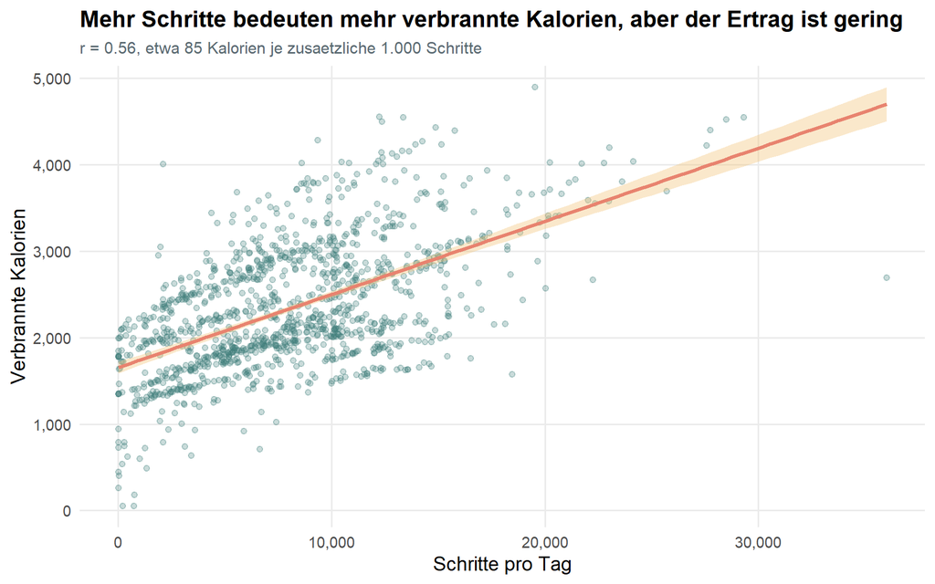

```r
ct <- cor.test(worn$total_steps, worn$calories)
m  <- lm(calories ~ total_steps, data = worn)

ggplot(worn, aes(total_steps, calories)) +
  geom_point(alpha = .28, colour = TEAL, size = 1.5) +
  geom_smooth(method = "lm", se = TRUE, colour = CORAL, fill = SAND) +
  scale_x_continuous(labels = comma) + scale_y_continuous(labels = comma) +
  labs(title = "Mehr Schritte bedeuten mehr verbrannte Kalorien, aber der Ertrag ist gering",
       subtitle = paste0("r = ", round(ct$estimate, 2), ", etwa ",
                         round(coef(m)[2] * 1000), " Kalorien je zusaetzliche 1.000 Schritte"),
       x = "Schritte pro Tag", y = "Verbrannte Kalorien") + theme_bb
```

**Warum das wichtig ist:** Der ansprechbare Hebel sind die 15.9 Sitzstunden, nicht die 22 aktiven Minuten. Sitzphasen zu unterbrechen ist fuer die Nutzenden eine deutlich niedrigere Huerde, als zusaetzliche Trainingseinheiten einzuplanen.

## Ergebnis 4: Aktivitaet ballt sich an zwei vorhersehbaren Spitzen

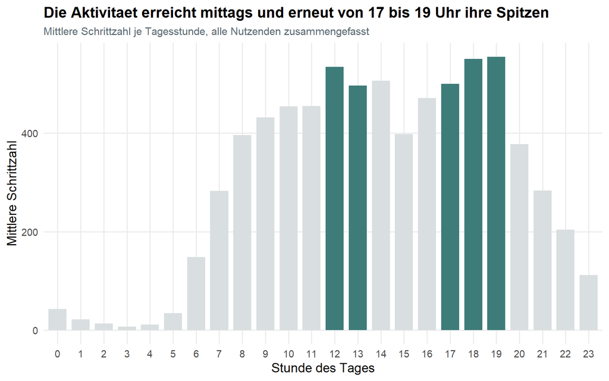

```r
by_hour <- hourly |>  group_by(hour) |>
  summarise(avg_steps = mean(step_total), .groups = "drop")

ggplot(by_hour |>  mutate(peak = hour %in% c(12, 13, 17, 18, 19)),
       aes(factor(hour), avg_steps, fill = peak)) +
  geom_col(width = .78) +
  scale_fill_manual(values = c(`FALSE` = GREY, `TRUE` = TEAL), guide = "none") +
  labs(title = "Die Aktivitaet erreicht mittags und erneut von 17 bis 19 Uhr ihre Spitzen",
       subtitle = "Mittlere Schrittzahl je Tagesstunde, alle Nutzenden zusammengefasst",
       x = "Stunde des Tages", y = "Mittlere Schrittzahl") + theme_bb
```

```r
by_hour |>  arrange(desc(avg_steps)) |>  head(5) |>
  transmute(Stunde = paste0(hour, ":00"), `Mittlere Schrittzahl` = round(avg_steps)) |>
  kable(caption = "Die fuenf aktivsten Stunden des Tages")
```

Die fuenf aktivsten Stunden des Tages

| Stunde | Mittlere Schrittzahl |
| --- | --- |
| 19:00 | 555 |
| 18:00 | 550 |
| 12:00 | 534 |
| 14:00 | 506 |
| 17:00 | 500 |

**Warum das wichtig ist:** Der Zeitpunkt von Benachrichtigungen ist bei den meisten Apps Raterei. In diesen Zeitfenstern sind die Nutzenden ohnehin in Bewegung und am ehesten fuer einen Impuls empfaenglich.

## Ergebnis 5: Die Haelfte aller Naechte bleibt unter gesundem Schlaf

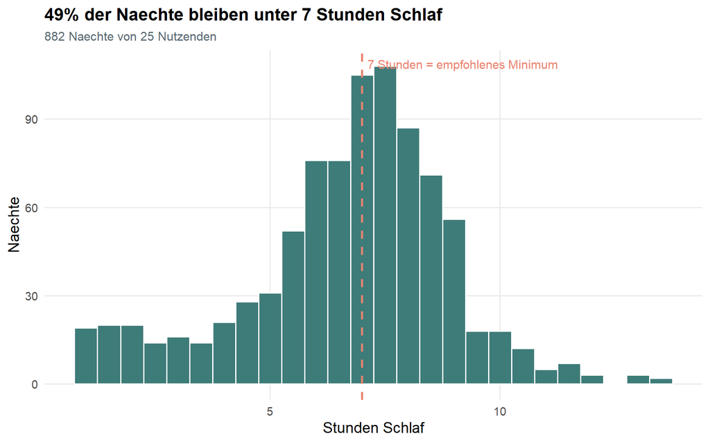

```r
ggplot(sleep, aes(hours_asleep)) +
  geom_histogram(binwidth = .5, fill = TEAL, colour = "white") +
  geom_vline(xintercept = 7, linetype = "dashed", colour = CORAL, linewidth = .8) +
  annotate("text", x = 7.12, y = Inf, vjust = 2, hjust = 0, colour = CORAL, size = 3.4,
           label = "7 Stunden = empfohlenes Minimum") +
  labs(title = paste0(percent(mean(sleep$hours_asleep < 7), 1),
                      " der Naechte bleiben unter 7 Stunden Schlaf"),
       subtitle = paste0(nrow(sleep), " Naechte von ", n_distinct(sleep$id), " Nutzenden"),
       x = "Stunden Schlaf", y = "Naechte") + theme_bb
```

Der mittlere Schlaf lag bei 6.68 Stunden, mit durchschnittlich 35.2 Minuten, die wach im Bett verbracht wurden.

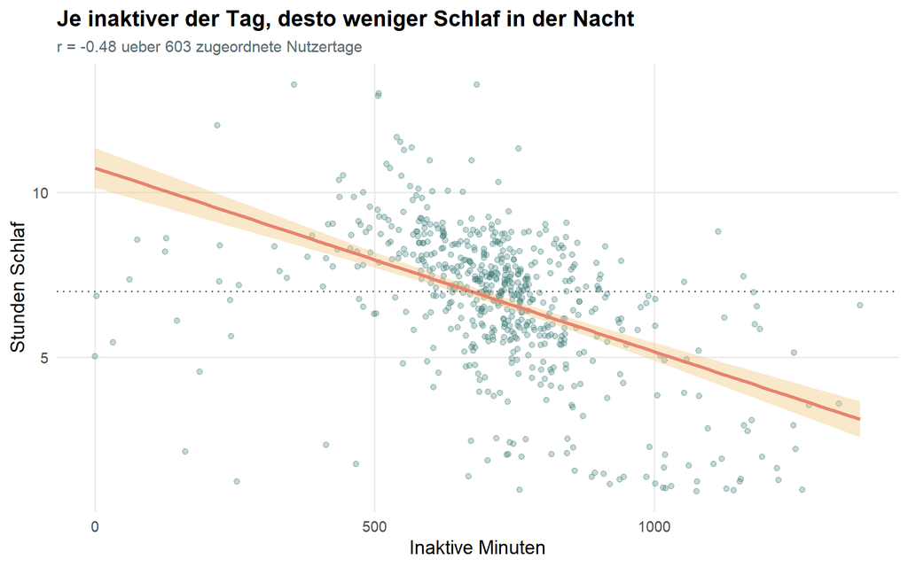

```r
ggplot(sa, aes(sedentary_minutes, hours_asleep)) +
  geom_point(alpha = .3, colour = TEAL, size = 1.5) +
  geom_smooth(method = "lm", se = TRUE, colour = CORAL, fill = SAND) +
  geom_hline(yintercept = 7, linetype = "dotted", colour = SLATE) +
  labs(title = "Je inaktiver der Tag, desto weniger Schlaf in der Nacht",
       subtitle = paste0("r = ", round(cor(sa$sedentary_minutes, sa$hours_asleep), 2),
                         " ueber ", nrow(sa), " zugeordnete Nutzertage"),
       x = "Inaktive Minuten", y = "Stunden Schlaf") + theme_bb
```

**Warum das wichtig ist:** Das ist der Zusammenhang im Datensatz, aus dem sich am meisten ableiten laesst. Die Aussage lautet nicht “mehr gehen, besser schlafen”, sondern **“weniger sitzen, besser schlafen”**, eine konkrete, belegbare und unterscheidbare Botschaft.

## Ergebnis 6: Die Nutzung bricht ein, sobald Aufwand noetig wird

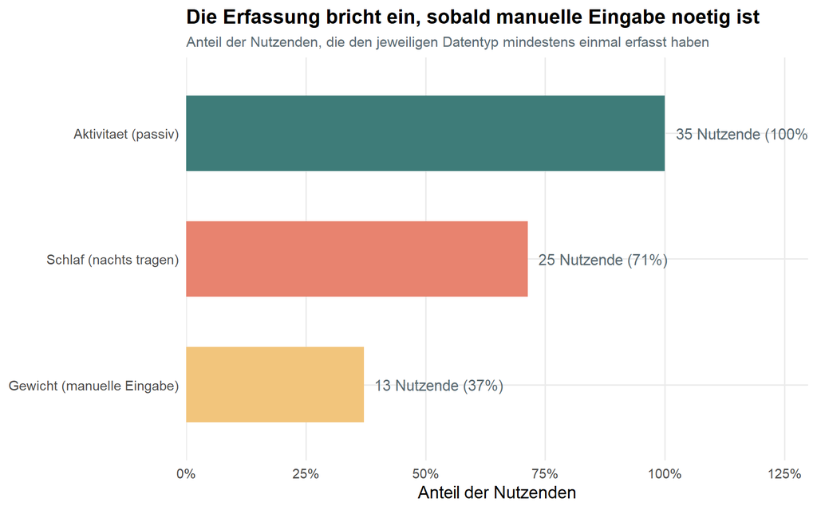

```r
adopt <- tibble(
  feature = c("Aktivitaet (passiv)", "Schlaf (nachts tragen)", "Gewicht (manuelle Eingabe)"),
  users   = c(n_distinct(daily$id), n_distinct(sleep$id), n_distinct(weight$id))
) |>  mutate(pct = users / n_users)

ggplot(adopt, aes(reorder(feature, pct), pct, fill = feature)) +
  geom_col(width = .6) +
  geom_text(aes(label = paste0(users, " Nutzende (", percent(pct, 1), ")")),
            hjust = -0.08, size = 3.8, colour = SLATE) +
  coord_flip() +
  scale_y_continuous(labels = percent, limits = c(0, 1.3), expand = c(0, 0)) +
  scale_fill_manual(values = c(TEAL, SAND, CORAL), guide = "none") +
  labs(title = "Die Erfassung bricht ein, sobald manuelle Eingabe noetig ist",
       subtitle = "Anteil der Nutzenden, die den jeweiligen Datentyp mindestens einmal erfasst haben",
       x = NULL, y = "Anteil der Nutzenden") + theme_bb
```

64.3% der Gewichtseintraege wurden von Hand eingetippt, mit einem Median von 2 Eintraegen je erfassender Person ueber den gesamten Zeitraum.

**Warum das wichtig ist:** Jede zusaetzliche Huerde kostet rund ein Drittel der Nutzenden. Funktionen, die manuelle Eingaben verlangen, werden unabhaengig von der Gestaltungsqualitaet nicht angenommen.

# 6. Handeln: Empfehlungen

> **Ergebnis 6: Die wichtigsten inhaltlichen Empfehlungen auf hoher Ebene**

## Antworten auf die drei Leitfragen

**1. Welche Trends gibt es bei der Nutzung intelligenter Geraete?** Die Geraete werden unregelmaessig getragen, im Median an 63% der Tage, wobei keine Person `80%` ueberschreitet. Die Aktivitaet bleibt deutlich hinter gesundheitspolitischen Zielen zurueck: Nur 34.0% der Tage erreichen 10.000 Schritte, und 15.9 Stunden des durchschnittlich erfassten Tages sind Sitzzeit. Die Aktivitaet konzentriert sich auf die Mittagszeit und den fruehen Abend. Der Schlaf ist kurz, 49.1% der Naechte bleiben unter sieben Stunden, und die Nutzung von Funktionen bricht ein, sobald manuelle Eingaben noetig werden.

**2. Wie lassen sich diese Trends auf Bellabeat-Kundinnen uebertragen?** Bellabeat-Kundinnen nutzen dieselben Geraetekategorien zu denselben Zwecken, also gelten dieselben Verhaltensgrenzen. Zwei uebertragen sich am unmittelbarsten. Erstens begrenzt die Tragequote alles: Die Funktionen von Bellabeat zu Stress, Schlaf und Zyklus setzen konsequentes Tragen voraus, weshalb die Schmuckform des Leaf eine echte Einschraenkung adressiert und nicht bloss eine aeusserliche. Zweitens passt der Zusammenhang von Sitzzeit und Schlaf genau zu Bellabeats bestehender Positionierung rund um ganzheitliches Wohlbefinden statt sportlicher Leistung.

**3. Wie koennen diese Trends die Marketingstrategie von Bellabeat beeinflussen?** Sie verschieben die Botschaft von Leistung zu Machbarkeit. Statt mit Fitbit und Apple ueber Schrittzahlen und Trainingsaufzeichnung zu konkurrieren, wo die Daten zeigen, dass die meisten Nutzenden scheitern, kann Bellabeat die niedrigere, erreichbarere und besser belegte Aussage besetzen: weniger sitzen, um besser zu schlafen.